# Offline Reinforcement Learning

## Introduction

[Reinforcement learning](https://en.wikipedia.org/wiki/Reinforcement_learning) (RL) is an area of machine learning concerned with how intelligent agents ought to take actions in an environment in order to maximize the notion of cumulative reward. State ($s$), action ($a$) and reward ($r$) are important terms in RL defined as follows:

1. **State** : Environment comprises a set of states. In [maze problem](https://en.wikipedia.org/wiki/Maze-solving_algorithm), start position, end position, and maze structure together form an environment and the current position defines the current state. In [recommendation system](https://en.wikipedia.org/wiki/Recommender_system), the inventory state defines the environment and the user context vector defines the state. There is no exact definition of the state, it varies from problem to problem.
2. **Action** : It represents actionable items at a given state. For a maze problem, UP, DOWN, LEFT, and RIGHT are possible actions, likewise, in the recommendation system, SELECT, and REJECT are possible actions.
3. **Reward** : It represents the current reward that an agent will get for taking action $a$ in state $s$. The objective is to maximize the total reward.

The objective of RL is to learn an optimal policy (that maximizes cumulative reward) $p$ from live interactions with the environment. The policy is defined as state-conditioned action probability, i.e. $p(s, a)=P(action=a|state=s)$. For simplicity, we will consider **single state environment** i.e. once an agent takes an action $a$, it reaches an end state and gets reward $r$.

The online learning algorithm goes as follows:

> Input : $s$, $\pi_k$  
> $a = \pi_k[s]$  
> $r = interaction(s,a)$  
> $\pi_{k+1} = updatePolicy(s,a,r)$

**Online learning framework** is not suitable in the real world due to the online interaction of the algorithm with the environment. Such live interactions may cause significant irreversible damage during learning. Getting offline data in such scenarios is feasible in industries like retail, healthcare, etc. In **Offline Reinforcement Learning** (ORL) setting, dataset $D$ is collected by some (potentially unknown) behavior policy $π_0$. This dataset is collected once and is not altered during training. The training process does not interact with the environment at all, and the policy is only deployed after being fully trained. In this blog, we will only talk about challenges in evaluating a policy with previously collected data. Once a fair mechanism is developed for evaluating a policy from the offline dataset, one can follow up on learning methods.

## Policy evaluation

Let we have log data $D_0 = \{(s_i, a_i, r_i)\}_{i=1}^{n}$ from policy $\pi_0$.  
$D_0$ is sampled i.i.d from the product distribution, i.e. $p(s_i,a_i,r_i) = p(s_i)*\pi_0(a_i|s_i)*p(r_i|s_i,a_i)$.  
The policy value (aka policy performance, utility, expected reward) is expressed as $\pi$ is $V(\pi) = \mathbb{E}_{p(s, a,r)}[r]$.  
If $D_0$ is sampled from evaluation policy $\pi_0$, then $\hat{V}(\pi_0; D_0) = \frac{1}{n}\sum_{i=1}^{n} r_i$  
In the above expression, the expectation is replaced by data mean i.e. $V(\pi_0) \approx \hat{V}(\pi_0; D_0)$ and it causes an exploration error in policy evaluation.

In off policy, goal is to evaluate policy $\pi_e$ with data collected from different policy $\pi_0$, i.e. $\hat{V}(\pi_e;D_0)$. We want $V(\pi_e) \approx \hat{V}(\pi_e; D_0)$, i.e. **how would policy $\pi_e$ have performed, if we had used it instead of $\pi_0$?**

Pros of offline policy evaluation are that it **could scale to an arbitrary number of candidate policies, without a risk of harm due to bad policy**. One major drawback of such evaluation is that it **might be less accurate and also has some critical assumptions and fundamental limits**. Before moving forward with the policy estimators, let's define the problem to work on.

## Problem definition

In this blog, we will evaluate policy for maze problem. A policy $\pi$ is good policy if it helps in reaching the end state in minimum time. Reward function is adjusted to support the objective.  
Let grid size is $m \times m$.  
State $s=[s_y,s_x]$ is defined as $2d$ coordinates $: (s_y, s_x) \in \{0,1,...m-1\}$. Let $S$ denote all states set.  
End state $s_e=[m-1, m-1]$  
There are 4 actions $A=\{\uparrow, \downarrow, \leftarrow, \rightarrow\}$  
Optimal_policy $\pi^*$ can be derived in straightforward way by keeping the objective in mind.

Consider an example, m=2. There will be total 4 states defined as

| state | $s_y$ | $s_x$ |
| --- | --- | --- |
| $s_0$ | $0$ | $0$ |
| $s_1$ | $0$ | $1$ |
| $s_2$ | $1$ | $0$ |
| $s_3$ | $1$ | $1$ |

$s_3$ is end state i.e. $s_e = s_3$  
**Optimal policy** $\pi^*=$

| state | $\uparrow$ | $\downarrow$ | $\leftarrow$ | $\rightarrow$ |
| --- | --- | --- | --- | --- |
| $s_0$ | $0$ | $0.5$ | $0$ | $0.5$ |
| $s_1$ | $0$ | $1$ | $0$ | $0$ |
| $s_2$ | $0$ | $0$ | $0$ | $1$ |

**Value function** is computed for an optimal policy using the **temporal differencing method**, i.e. $v_t[s_i] \leftarrow v_t[s_i] + \alpha (\gamma v_{t+1}[s_i] - v_t[s_i])$, where $v_{t+1}[s_i] = \sum_{a \in A} \pi^*(a|s_i)*v_t[s'_i]$, $\gamma$ is a discount factor and $\alpha$ is learning rate.

For above example, $v_{\pi^*}=$

| $64.06$ | $69.47$ |
| --- | --- |
| $69.91$ | $100$ |

**Reward** for any input $(s,a,s')$ is defined as

> if $s'$ is not feasible : $r=-1$  
> else $r = v_{\pi^*}[s']$

The above reward function transforms the maze problem into a single-state problem. So for any state, action tuple $(s,a)$, expected reward $r$ is computed with the help of $v_{\pi^*}$. It generates data tuple i.e. $(s,a,r)$.

To **generate data** from a random policy $\pi$, follow steps:

> Sample state $s \in S$  
> Sample action $a \in \pi[s]$  
> Get next state $s + a \rightarrow s'$  
> If $s'$ is feasible state, $r=v[s']$ otherwise -1  
> return $(s,a,r)$

Let's revisit the steps discussed so far:

1. Create a grid of desired grid size and define end state.
2. Generate the optimal policy $\pi^*$.
3. Compute value function using optimal policy $v_{\pi^*}$.
4. Reward for any feasible transition $r(s,a,s') = v_{\pi^*}[s']$.
5. Generate data for a new policy $\pi$.

In this blog, we will try to estimate the value of policy $\pi^*$ from random policy-generated dataset $D_{\pi}$ and compare $\hat{V}(\pi^*;D_{\pi})$ with $\hat{V}(\pi^*;D_{\pi^*})$.

Hypothesis is that $\hat{V}(\pi^*;D_{\pi})$ should be close to $\hat{V}(\pi^*;D_{\pi^*})$ for a good estimator, i.e. an estimator should be able to estimate true value of $V(\pi^*)$ even if sampled data $D$ is coming from another policy $\pi$.

## Bandit formulation

For **single state model**, [Multi-armed bandit](https://en.wikipedia.org/wiki/Multi-armed_bandit) (MAB) is the best well-defined formulation for it. Mathematically we can define MAB as follows:

Let,

1. $S=\{s_0, s_1, ...\}$ is the state set. It is also referred to as context in MAB.
2. $A=\{a_0, a_1, ...\}$ is action set and $|A|=K$.
3. $R=\{r_1, r_2, ...\}$ is reward set, associated with each action and $r_k \in R$ is representing reward distribution of $a_k \in A$ action. For example, $r_k = \mathcal{N}(\mu_k,\,\sigma^{2})$.
4. Policy $\pi = p(a_i|s_i)$ represents a distribution over action space conditioned on input state.

Policy can be evaluated as follows,

1. Dataset $D_{\pi}=\{(s_i, a_i, r_i)\}_{i=1}^{n}$ is generated by $n$ interactions of MAB using policy $\pi$. Expected reward is defined as $\mathbb{E}[r] = \sum_{i=1}^{n}r_i$ = $\hat{V}(\pi; D_{\pi}) \sim V(\pi)$.
2. Our goal is to evaluate the policy $\pi_e$ using a dataset $D_{\pi_0}$ generated using behavior policy $\pi_0$. Hypothesis is $\hat{V}(\pi_e; D_{\pi_0}) \sim V(\pi_e)$.

## Import libraries

This is an scratch implementation. So numpy and matplotlib libraries will suffice the requirement.

```python
from IPython.display import display, HTML
display(HTML("<style>.container { width:100% !important; }</style>"))

import numpy as np
import sys
import matplotlib.pyplot as plt
plt.rcParams["figure.figsize"] = (8,6)

import warnings
warnings.filterwarnings("ignore")
```

## Agent class

Agent class will have following functions:

1. **optimalPolicy** : It returns the optimal policy $\pi^*$ for a given grid and end_state.
2. **normalizePolicy** : It ensures $\sum_{a \in A} \pi(a|s)=1, \forall s \in \{S-s_{end}\}$
3. **getFeasibleState** : It returns next state $s'$ for $(s,a)$ input state, action tuple list and also returns which $(s,a)$ is feasiable in input list.
4. **getNewValue** : It applies **Temporal Differencing** method to get the next value.
5. **iteration** : It applies single iteration of **getNewValue** to all $s \in S$.
6. **value2Policy** : Given a value matrix, it returns policy. $\pi[s] = $ softmax $([r(s,a) $ for $ a \in A])$
7. **getValue** : It returns value matrix for a given policy $\pi$ by running multiple **iteration** till convergence.
8. **getSampleData** : It generates a sample data $(s,a,r)$ for a given policy $\pi$.
9. **policyValue** : It estimates the policy value $\hat{V}(\pi; D_{\pi})$ for a given policy $\pi$.
10. **policyValueIPSEstimate** : It estimates policy value $\hat{V}(\pi^*; D_{\pi})$ for any policy generated data $D_{\pi}$ using specified **estimator**.

```python
class Agent():
    def __init__(self, grid_size=3,
                 action=None,
                 policy=None,
                 value=None

                 ):
        self.grid_size = grid_size
        self.n_state = grid_size**2
        self.action2Index = lambda a : self.action.tolist().index(list(a))
        self.state2Index = lambda s : s[0]*self.grid_size + s[1]

        self.action = np.asarray([[-1,0],[1,0],[0,-1],[0,1]]) if action is None else action
        self.n_action = len(self.action)
        self.policy = self.normalizePolicy(np.random.rand(self.n_state,self.n_action)) if policy is None else policy
        self.value = np.random.rand(grid_size,grid_size) if value is None else value
        self.end_state = [grid_size-1, grid_size-1]
        self.target_reward = 100
        self.target_penalty = -self.target_reward*0.01
        self.value[tuple(self.end_state)] = self.target_reward
        self.optimal_policy = self.optimalPolicy()
        self.value = self.getValue(policy=self.optimal_policy)

    def optimalPolicy(self):
        optimal_policy = np.zeros(self.policy.shape)
        for y in range(self.grid_size):
            for x in range(self.grid_size):
                state = [y,x]
                if state == self.end_state:
                    continue
                next_state, _ = self.getFeasibleState(state)
                dv = abs(self.end_state-next_state).sum(axis=1)
                optimal_actions = np.argwhere(dv==dv.min())[:,0]
                idx = y*self.grid_size + x
                optimal_policy[idx][optimal_actions] = 1/len(optimal_actions)
        return optimal_policy

    def normalizePolicy(self, policy):
        policy_sum = policy.sum(axis=1, keepdims=True)
        for i,s in enumerate(policy_sum):
            policy[i] = policy[i]/s if s!=0 else policy[i]
        return policy

    def getFeasibleState(self, state):
        next_state = state+self.action
        return next_state, [i for i,(sy,sx) in enumerate(next_state) if (0<=sx<self.grid_size) and ((0<=sy<self.grid_size))]

    def getNewValue(self, state, value, policy, lr=0.1, discount=0.8):
        next_state, feasible_index = self.getFeasibleState(state)
        p_action = policy[state[0]*self.grid_size + state[1]]
        v_action = [value[tuple(s)] if i in feasible_index else self.target_penalty for i,s in enumerate(next_state)]
        v_pred = (p_action*v_action).sum()*discount
        v_curr = value[tuple(state)]
        v_new = v_curr + lr*(v_pred-v_curr)
        return min(v_new, self.target_reward) + (self.target_reward*0.10)*(np.random.rand()-0.5)

    def iteration(self, curr_value, policy):
        new_value = curr_value.copy()
        for y in range(curr_value.shape[0]):
            for x in range(curr_value.shape[1]):
                state = [y,x]
                if state == self.end_state:
                    continue
                new_value[y,x] = self.getNewValue(state, curr_value, policy)
        return new_value

    def value2Policy(self, value):
        policy = np.zeros(self.policy.shape)
        for y in range(self.grid_size):
            for x in range(self.grid_size):
                state = [y,x]
                idx = y*self.grid_size + x
                if state == self.end_state:
                    continue
                next_state, feasible_index = self.getFeasibleState(state)
                v_action = np.asarray([value[tuple(s)] if i in feasible_index else -1 for i,s in enumerate(next_state)])
                policy[idx][feasible_index] = np.exp(v_action)/sum(np.exp(v_action))
        return policy

    def getValue(self, curr_value=None, policy=None):
        curr_value = self.value if curr_value is None else curr_value
        policy = self.policy if policy is None else policy
        for i in range(250):
            new_value = self.iteration(curr_value, policy)
            error = abs((curr_value-new_value)).sum()
            curr_value = new_value
            if error<0.1:
                break
        return curr_value


    def getSampleData(self, policy, data_n=100):
        excess_sample_data = np.random.randint(low=0, high=self.grid_size, size=(int(data_n*2),2), dtype=int)
        data_state = []
        cnt = 0
        for dy,dx in excess_sample_data:
            if [dy,dx]!=self.end_state:
                data_state.append([dy,dx])
                cnt+=1
                if cnt==data_n:
                    break
        data_state = np.asarray(data_state)
        data_action = np.asarray([self.action[np.random.choice([0,1,2,3], size=1, replace=True, p=policy[sy*self.grid_size+sx])[0]] for (sy,sx) in data_state])
        data_next_state = data_state + data_action
        feasible_state_mask = [(0<=sx<self.grid_size) and (0<=sy<self.grid_size) for (sy,sx) in data_next_state]
        data_value = np.asarray([self.value[sx,sy] if m else self.target_penalty for m,(sx,sy) in zip(feasible_state_mask, data_next_state)])
        return data_state, data_action, data_value

    def policyValue(self, policy, data=None, data_n=100):
        data = self.getSampleData(policy, data_n) if data is None else data
        state, action, reward = data
        return reward.mean()

    def IPS(self, p0,p1,r):
        return (p1/(p0+1e-4))*r

    def CIPS(self, p0, p1, r):
        wr = self.IPS(p0,p1,r)
        l,h = np.quantile(wr, 0.10), np.quantile(wr, 0.90)
        wr = np.clip(a=wr, a_min=l, a_max=h)
        return wr

    def SNIPS(self, p0, p1, r):
        wr = self.IPS(p0,p1,r)
        l = self.IPS(p0,p1,1).mean()
        return wr/l

    def policyValueIPSEstimate(self, policy0, policy1, data0, method=None, use_true=False):
        method = self.IPS if method is None else method
        state, action, reward = data0
        n = len(state)

        action_index = [self.action2Index(a) for a in action]
        state_index = [self.state2Index(s) for s in state]

        policy0_e = np.zeros(policy1.shape)
        for s,a in zip(state_index, action_index):
            policy0_e[s,a]+=1
        policy0_e = self.normalizePolicy(policy0_e)

        if use_true:
            policy0_e = policy0.copy()

        p0 = np.asarray([policy0_e[s][a] for (s,a) in zip(state_index, action_index)])
        p1 = np.asarray([policy1[s][a] for (s,a) in zip(state_index, action_index)])
        dist = self.IPS(p0,p1,1)
        wr = method(p0, p1, reward)
        return wr.sum()/n, dist.max()
```

To start the experiment,

1. Create a grid of size = $7$.
2. Optimal policy $\pi^*$ is computed during agent init phase.
3. Compute $\hat{V}(\pi^*)$ using **policyValue()** function. This function implicitly generates $D_{\pi^*}$ to compute $\hat{V}(\pi^*)$.
4. Create a new policy $\pi$ randomly and generate data $D_{\pi} = \{(s_i, a_i, r_i)\}_{i=1}^{100}$.

```python
grid_size = 7
agent = Agent(grid_size=grid_size)
v_gt = agent.policyValue(agent.optimal_policy.copy(), data_n=2500)
```

## Model free estimators

From this section, will introduce different estimators to evaluate $\hat{V}(\pi^*; D_{\pi})$. In this blog, we will talk about some model free policy evaluation methods that represents only the subset of existing research.

### Inverse Propensity Score (IPS)

IPS estimator is defined as $$\hat{V}_{IPS}(\pi_e; D_0) = \frac{1}{n} \sum_{i=1}^{n} \frac{\pi_e(a_i | s_i)}{\pi_0(a_i | s_i)} * r_i$$

It corrects the policy drift $\pi_0 - \pi_e$ by weighting reward by the ratio of the evaluation and logging policies. In our case, $\pi_e=\pi^*$ and $\pi_0=\pi$.  
IPS is an **unbiased estimator** but has **high variance**. High variance is caused by the denominator term in weighted reward i.e. $\pi_0(a|s)$.

Following plot shows the variation in $\hat{V}(\pi^*; D_{\pi})$ for different $\pi$.

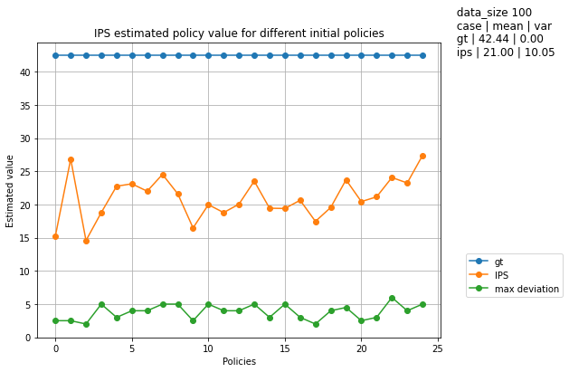

```python
data_n = 100
v_gt_list, v_ips_list, dist_list = [], [], []
for it in range(25):
    policy0 = agent.normalizePolicy(np.random.rand(agent.n_state, agent.n_action))
    data0 = agent.getSampleData(policy0, data_n)
    v_ips, dist = agent.policyValueIPSEstimate(policy0, agent.optimal_policy, data0, agent.IPS)
    v_ips_list.append(v_ips)
    v_gt_list.append(v_gt)
    dist_list.append(dist)

v_gt_list = np.asarray(v_gt_list)
v_ips_list = np.asarray(v_ips_list)
dist_list = np.asarray(dist_list)
s = ' data_size %d \n case | mean | var \n gt | %0.2f | %0.2f \n ips | %0.2f | %0.2f'%(data_n, np.mean(v_gt_list),np.var(v_gt_list),np.mean(v_ips_list),np.var(v_ips_list))

plt.close('all')
plt.title('IPS estimated policy value for different initial policies')
plt.text(len(v_gt_list)+1,v_gt_list.mean(),s,fontsize=12)
plt.plot(v_gt_list, '-o', label='gt')
plt.plot(v_ips_list, '-o', label='IPS')
plt.plot(dist_list, '-o', label='max deviation')
plt.xlabel('Policies')
plt.ylabel('Estimated value')
plt.legend(bbox_to_anchor=(1.05, 0.3), loc='upper left')
plt.grid()
plt.show()
```

### IPS Observations

1. IPS seems like **under predicting** $\hat{V}(\pi^*, D_{\pi})$ for all initial policies. It is happening because **data estimated policy** $\hat{\pi}$ is used instead of true data policy $\pi$. This error reduces as data size increases.
2. Theoretically the variance should increase for larger deviation between $\pi$ and $\pi^*$. It is hard to observe the same due to $\hat{\pi}$.
3. Theoretically IPS is an unbiased estimator. It means $\hat{V}(\pi^*, D_{\pi}) \rightarrow V(\pi^*)$ as data size increases. We have observed the same from above plot.

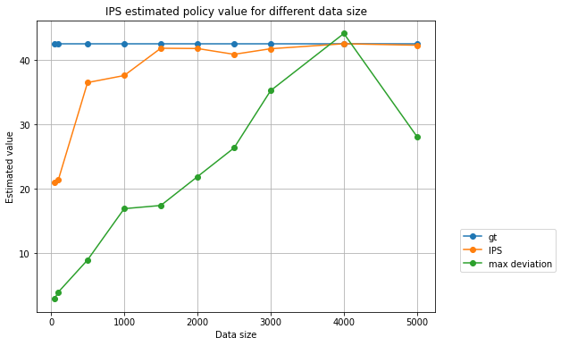

```python
policy0 = agent.normalizePolicy(np.random.rand(agent.n_state, agent.n_action))
v_gt_list, v_ips_list, dist_list = [], [], []
data_n_list = [50,100,500,1000,1500,2000, 2500, 3000, 4000, 5000]
for data_n in data_n_list:
    data0 = agent.getSampleData(policy0, data_n)
    v_ips, dist = agent.policyValueIPSEstimate(policy0, agent.optimal_policy, data0, agent.IPS)
    v_ips_list.append(v_ips)
    v_gt_list.append(v_gt)
    dist_list.append(dist)

v_gt_list = np.asarray(v_gt_list)
v_ips_list = np.asarray(v_ips_list)
dist_list = np.asarray(dist_list)

plt.close('all')
plt.title('IPS estimated policy value for different data size')
plt.plot(data_n_list, v_gt_list, '-o', label='gt')
plt.plot(data_n_list, v_ips_list, '-o', label='IPS')
plt.plot(data_n_list, dist_list, '-o', label='max deviation')
plt.xlabel('Data size')
plt.ylabel('Estimated value')
plt.legend(bbox_to_anchor=(1.05, 0.3), loc='upper left')
plt.grid()
plt.show()
```

### Clipped Inverse Propensity Score (CIPS) Estimator

CIPS clips large weights by introducing a hyperparameter. $$\hat{V}_{CIPS}(\pi_e; D_0, \lambda) = \frac{1}{n} \sum_{i=1}^{n} \min\{\frac{\pi_e(a_i | s_i)}{\pi_0(a_i | s_i)}, \lambda\}*r_i$$ CIPS has lower variance than IPS, but neither unbiased nor consistent.

### Self-Normalized IPS (SNIPS) Estimator

SNIPS rescales the estimate of the vanila IPS $$\hat{V}_{SNIPS}(\pi_e; D_0) = \frac{\frac{1}{n} \sum_{i=1}^{n} \frac{\pi_e(a_i | s_i)}{\pi_0(a_i | s_i)} * r_i}{\frac{1}{n} \sum_{i=1}^{n} \frac{\pi_e(a_i | s_i)}{\pi_0(a_i | s_i)}} = \frac{\sum_{i=1}^{n} \frac{\pi_e(a_i | s_i)}{\pi_0(a_i | s_i)} * r_i}{\sum_{i=1}^{n} \frac{\pi_e(a_i | s_i)}{\pi_0(a_i | s_i)}}$$ SNIPS is consistent, but not unbiased. It is stable (in some sense), has no hyperparameters and works well empirically.

Following plot compares IPS, CIPS and SNIPS for different behavior policies.

```python
output = {}
for it in range(25):
    policy0 = agent.normalizePolicy(np.random.rand(agent.n_state, agent.n_action))
    v_gt_list, v_ips_list, v_cips_list, v_snips_list, dist_list = [], [], [], [], []
    data_n_list = [25, 100, 500, 1000, 1500]
    for data_n in data_n_list:
        data0 = agent.getSampleData(policy0, data_n)
        v_ips, dist = agent.policyValueIPSEstimate(policy0, agent.optimal_policy, data0, agent.IPS)
        v_cips, _ = agent.policyValueIPSEstimate(policy0, agent.optimal_policy, data0, agent.CIPS)
        v_snips, _ = agent.policyValueIPSEstimate(policy0, agent.optimal_policy, data0, agent.SNIPS)

        v_gt_list.append(v_gt)
        v_ips_list.append(v_ips)
        v_cips_list.append(v_cips)
        v_snips_list.append(v_snips)
        dist_list.append(dist)

    data = {'v_gt':v_gt_list,
            'v_ips':v_ips_list,
            'v_cips':v_cips_list,
            'v_snips':v_snips_list,
            'dist':dist_list,
            'data_n': data_n_list
            }
    output[it] = data
```

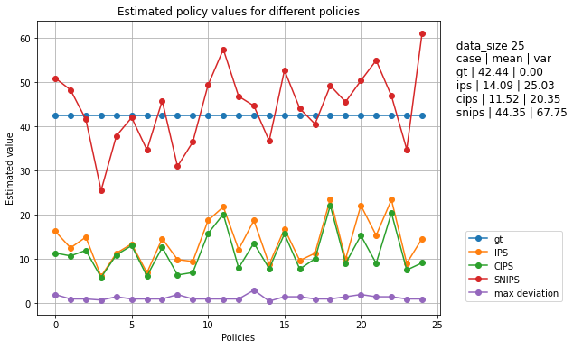

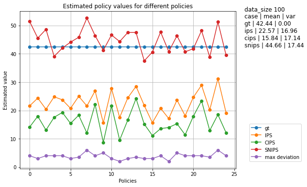

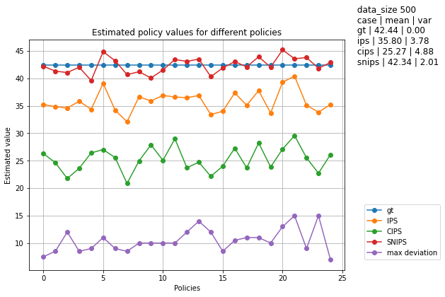

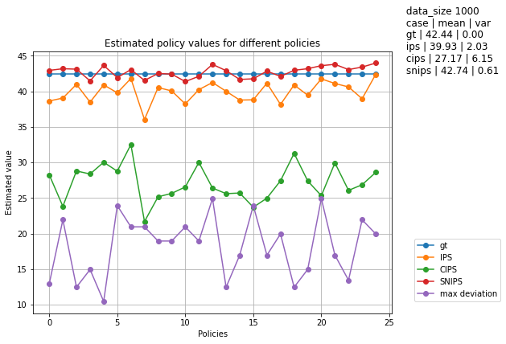

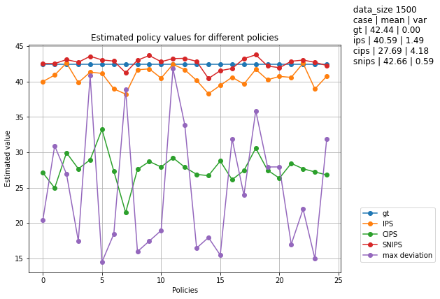

```python
def visualizeOutput(output, title):
    v_gt_list = np.zeros((len(output[0]['v_gt']), len(output)))
    v_ips_list = np.zeros((len(output[0]['v_gt']), len(output)))
    v_cips_list = np.zeros((len(output[0]['v_gt']), len(output)))
    v_snips_list = np.zeros((len(output[0]['v_gt']), len(output)))
    dist_list = np.zeros((len(output[0]['v_gt']), len(output)))
    data_n_list = []
    for k,v in output.items():
        v_gt_list[:,k] = v['v_gt']
        v_ips_list[:,k] = v['v_ips']
        v_cips_list[:,k] = v['v_cips']
        v_snips_list[:,k] = v['v_snips']
        dist_list[:,k] = v['dist']
        data_n_list = v['data_n']

    for data in zip(data_n_list, v_gt_list, v_ips_list, v_cips_list, v_snips_list, dist_list):
        n, v_gt, v_ips, v_cips, v_snips, dist = data

        s = ' data_size %d \n case | mean | var \n gt | %0.2f | %0.2f \n ips | %0.2f | %0.2f \n cips | %0.2f | %0.2f \n snips | %0.2f | %0.2f'%(n, np.mean(v_gt),np.var(v_gt),np.mean(v_ips),np.var(v_ips), np.mean(v_cips), np.var(v_cips), np.mean(v_snips), np.var(v_snips))

        plt.close('all')
        plt.title(title)
        plt.text(len(v_gt)+1,v_gt.max(),s,fontsize=12)
        plt.plot(v_gt, '-o', label='gt')
        plt.plot(v_ips, '-o', label='IPS')
        plt.plot(v_cips, '-o', label='CIPS')
        plt.plot(v_snips, '-o', label='SNIPS')
        plt.plot(dist, '-o', label='max deviation')
        plt.xlabel('Policies')
        plt.ylabel('Estimated value')
        plt.legend(bbox_to_anchor=(1.05, 0.3), loc='upper left')
        plt.grid()
        plt.show()
        print('-'*100)

title = 'Estimated policy values for different policies'
visualizeOutput(output, title)
```

## Observations

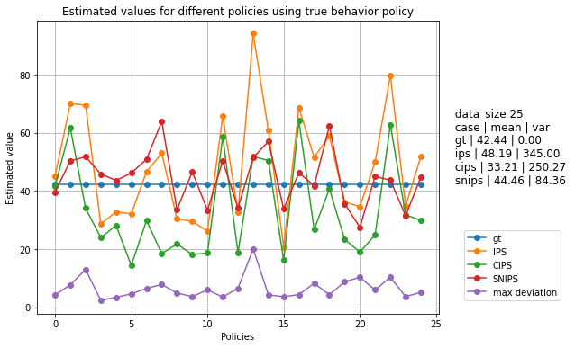

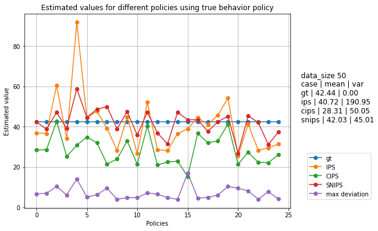

```python
output = {}
for it in range(25):
    policy0 = agent.normalizePolicy(np.random.rand(agent.n_state, agent.n_action))
    v_gt_list, v_ips_list, v_cips_list, v_snips_list, dist_list = [], [], [], [], []
    data_n_list = [25, 50]
    for data_n in data_n_list:
        data0 = agent.getSampleData(policy0, data_n)
        v_ips, dist = agent.policyValueIPSEstimate(policy0, agent.optimal_policy, data0, agent.IPS, use_true=True)
        v_cips, _ = agent.policyValueIPSEstimate(policy0, agent.optimal_policy, data0, agent.CIPS, use_true=True)
        v_snips, _ = agent.policyValueIPSEstimate(policy0, agent.optimal_policy, data0, agent.SNIPS, use_true=True)

        v_gt_list.append(v_gt)
        v_ips_list.append(v_ips)
        v_cips_list.append(v_cips)
        v_snips_list.append(v_snips)
        dist_list.append(dist)

    data = {'v_gt':v_gt_list,
            'v_ips':v_ips_list,
            'v_cips':v_cips_list,
            'v_snips':v_snips_list,
            'dist':dist_list,
            'data_n': data_n_list
            }
    output[it] = data

visualizeOutput(output, title='Estimated values for different policies using true behavior policy')
```

## Conclusion

As stated in a prior study ([Counterfactual Learning and Evaluation for Recommender Systems](https://sites.google.com/cornell.edu/recsys2021tutorial)), *there’s no single winner. One has to understand the pros and cons to make the right choices. SNIPS is enough for easy settings it works well without any hyperparameters but fails in challenging settings.* As there is no interaction of the model with the environment during the learning phase, exploration error will always be in learning methods. Extrapolation error is an error in off-policy evaluation which is introduced by the mismatch between the dataset and true state-action visitation of the evaluation policy. The cause of extrapolation error can be attributed to several related factors:

1. **Absent data** : If (s,$\pi_e(s)$) is unavailable, it is approximated using $D_{\pi0}$ dataset that causes an error.
2. **Model bias** : This is the error introduced in the temporal differencing method. It is not observed in a single-state model but may cause a significant deterioration in MDP.
3. **Behavior policy approximation** : We approximate behavior policy $\pi_0$ using dataset $D_{\pi_0}$ and this leads to high bias.

Detailed exploration error analysis is present in [Off-Policy Deep Reinforcement Learning without Exploration](https://arxiv.org/pdf/1812.02900.pdf) for reference.

## Reference

1. [Off-Policy Deep Reinforcement Learning without Exploration](https://arxiv.org/pdf/1812.02900.pdf)
2. [PLAS: Latent Action Space for Offline Reinforcement Learning](https://offline-rl-neurips.github.io/pdf/17.pdf)
3. [Addressing Extrapolation Error in Deep Offline Reinforcement Learning](https://offline-rl-neurips.github.io/pdf/41.pdf)
4. [ConQUR: Mitigating Delusional Bias in Deep Q-learning](https://www.cs.toronto.edu/~cebly/Papers/CONQUR_ICML_2020_camera_ready.pdf)
5. [Distilled Thompson Sampling: Practical and Efficient Thompson Sampling via Imitation Learning](https://offline-rl-neurips.github.io/pdf/47.pdf)
6. [A Contextual-Bandit Approach to Personalized News Article Recommendation](http://rob.schapire.net/papers/www10.pdf)
7. [Counterfactual risk minimization](https://arxiv.org/pdf/1502.02362.pdf)
8. [Stabilizing Off-Policy Q-Learning via Bootstrapping Error Reduction](https://arxiv.org/pdf/1906.00949.pdf)
9. [Conservative Q-Learning for Offline Reinforcement Learning](https://arxiv.org/pdf/2006.04779.pdf)
10. [COG: Connecting New Skills to Past Experience with Offline Reinforcement Learning](https://arxiv.org/pdf/2010.14500.pdf)
11. [Offline Reinforcement Learning: Tutorial, Review, and Perspectives on Open Problems](https://arxiv.org/pdf/2005.01643.pdf)
12. [A Survey on Offline Reinforcement Learning: Taxonomy, Review, and Open Problems](https://arxiv.org/pdf/2203.01387.pdf)
13. [Counterfactual Learning and Evaluation for Recommender Systems](https://sites.google.com/cornell.edu/recsys2021tutorial)